# Forecasting: Principles and Practice – 2nd Edition

Dibz

2023-04-01

## Chapter 2 - Time series graphics

# 2.1 $ts$ objects

$ts$ function turn data to time series

```r
y <- ts(c(123,39,78,52,110),start = 2012)
```

Suppose we have vector z, we can write

```r
z <- runif(24,1,100)
y <- ts(z, start = 2003, frequency = 12)
```

# 2.2 Time plots

Examples

```r
library(fpp2)
```

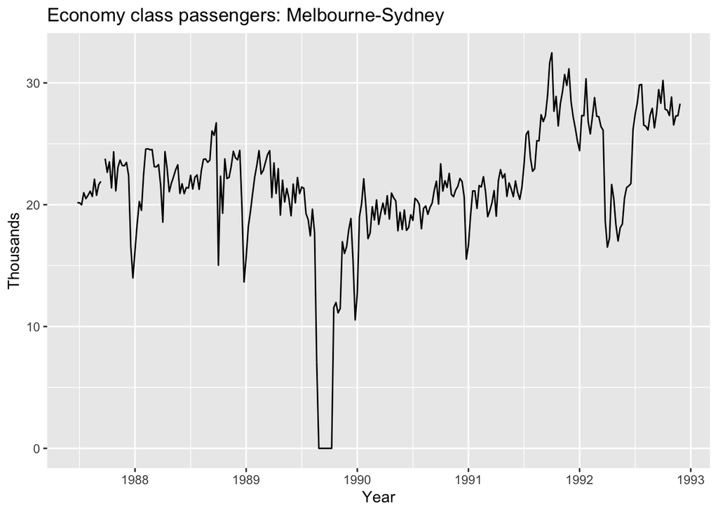

```r
autoplot(melsyd[,"Economy.Class"]) +
  ggtitle("Economy class passengers: Melbourne-Sydney") +
  xlab("Year") +
  ylab("Thousands")
```

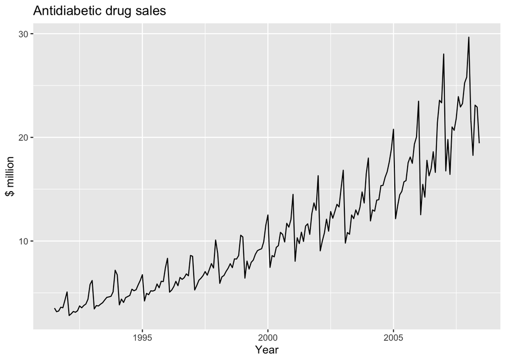

```r
autoplot(a10) +
  ggtitle("Antidiabetic drug sales") +
  ylab("$ million") +
  xlab("Year")
```

# 2.3 Times series patterns

**Trend** - long term increase or decrease  
**Seasonal** - pattern occurs when data is affected by seasonal factors. Usually, fix and known frequency.  
**Cyclic** - pattern occurs not in fix frequency and usually at least 2 years.

# 2.4 Seasonal plots

To identify seasonality

Examples

**Seasonal plot**

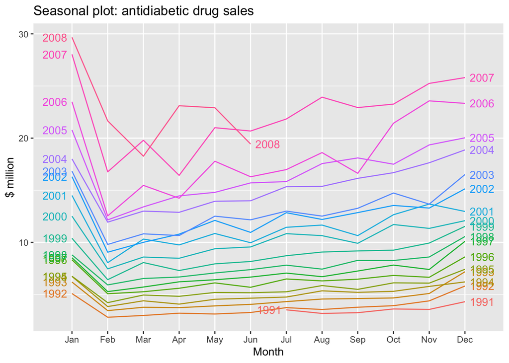

```r
ggseasonplot(a10, year.labels=TRUE, year.labels.left=TRUE) +
  ylab("$ million") +
  ggtitle("Seasonal plot: antidiabetic drug sales")
```

**Polar plot**

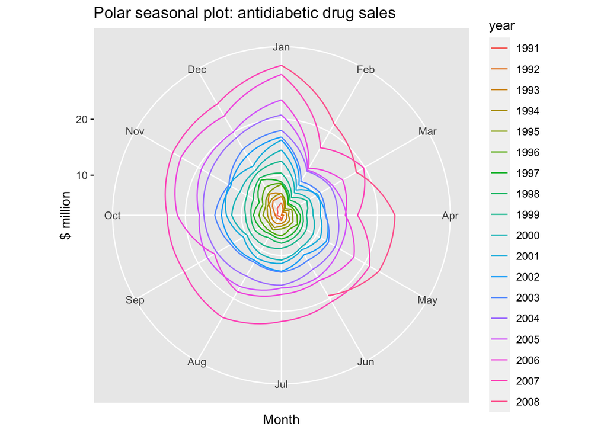

```r
ggseasonplot(a10, polar=TRUE) +
  ylab("$ million") +
  ggtitle("Polar seasonal plot: antidiabetic drug sales")
```

**Seasonal subseries plot**

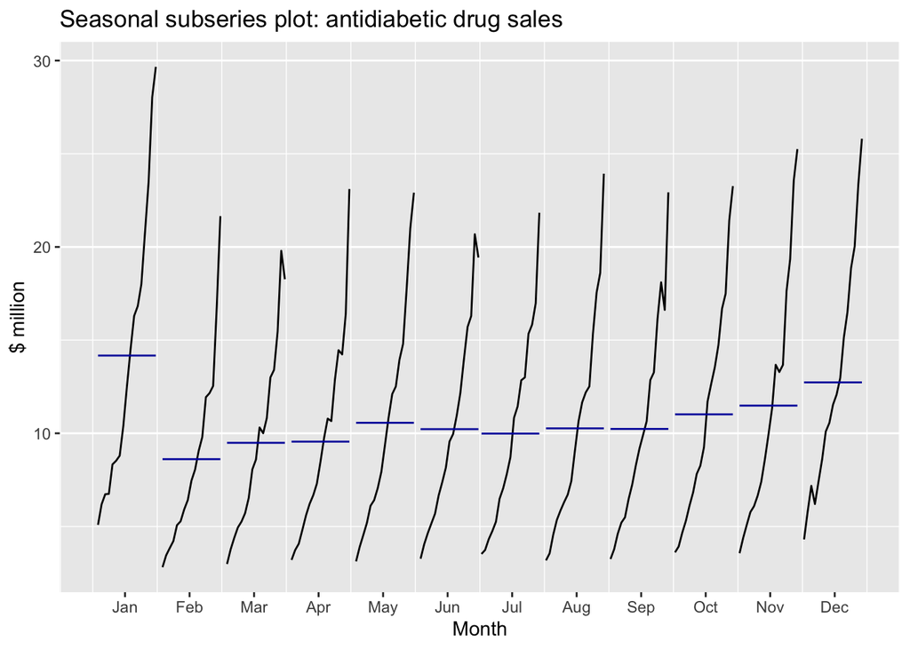

```r
ggsubseriesplot(a10) +
  ylab("$ million") +
  ggtitle("Seasonal subseries plot: antidiabetic drug sales")
```

# 2.6 Scatter plot

Use to explore relationship between time series.

Examples

Data to time

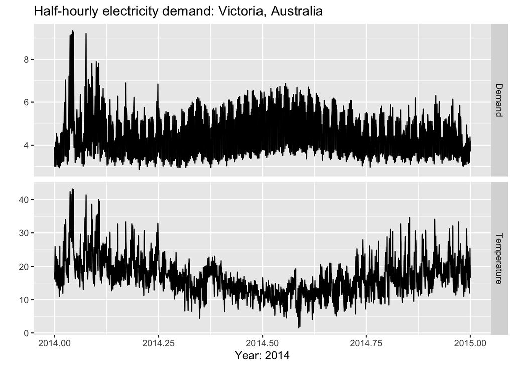

```r
autoplot(elecdemand[,c("Demand","Temperature")], facets=TRUE) +
  xlab("Year: 2014") + ylab("") +
  ggtitle("Half-hourly electricity demand: Victoria, Australia")
```

Variable to variable

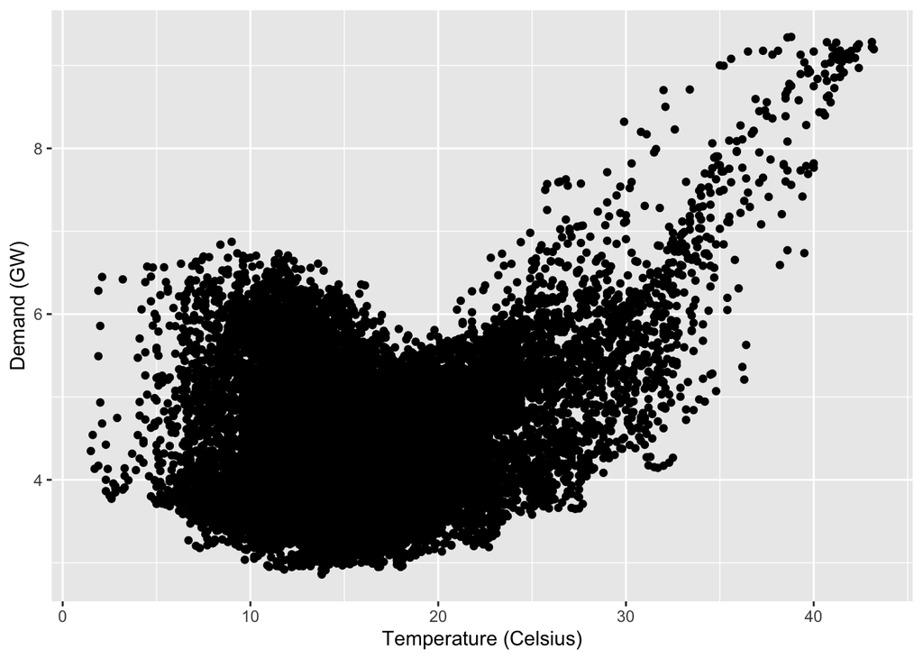

```r
qplot(Temperature, Demand, data=as.data.frame(elecdemand)) +
  ylab("Demand (GW)") + xlab("Temperature (Celsius)")
```

Multivariable to time

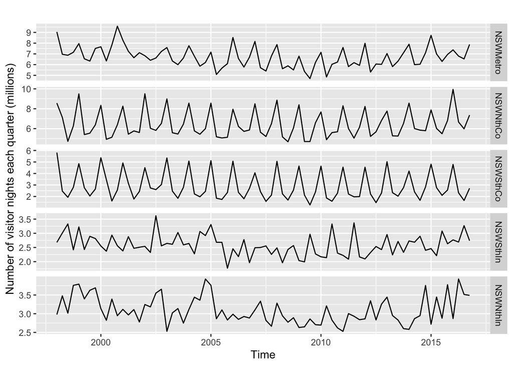

```r
autoplot(visnights[,1:5], facets=TRUE) +
  ylab("Number of visitor nights each quarter (millions)")
```

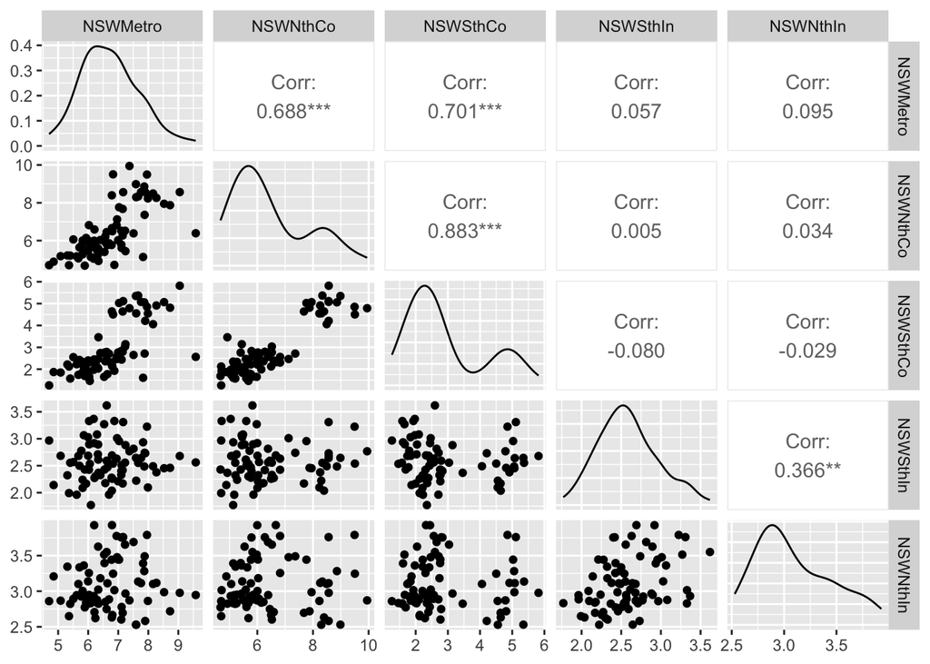

```r
GGally::ggpairs(as.data.frame(visnights[,1:5]))
```

**Correlation** Linear relationship between variables.

$r = \frac{\sum(x_t-\bar{x})(y_t-\bar{y})}{\sqrt{\sum(x_t-\bar{x})^2}{\sqrt{\sum(y_t-\bar{y})^2}}}$

# 2.7 Lag plots

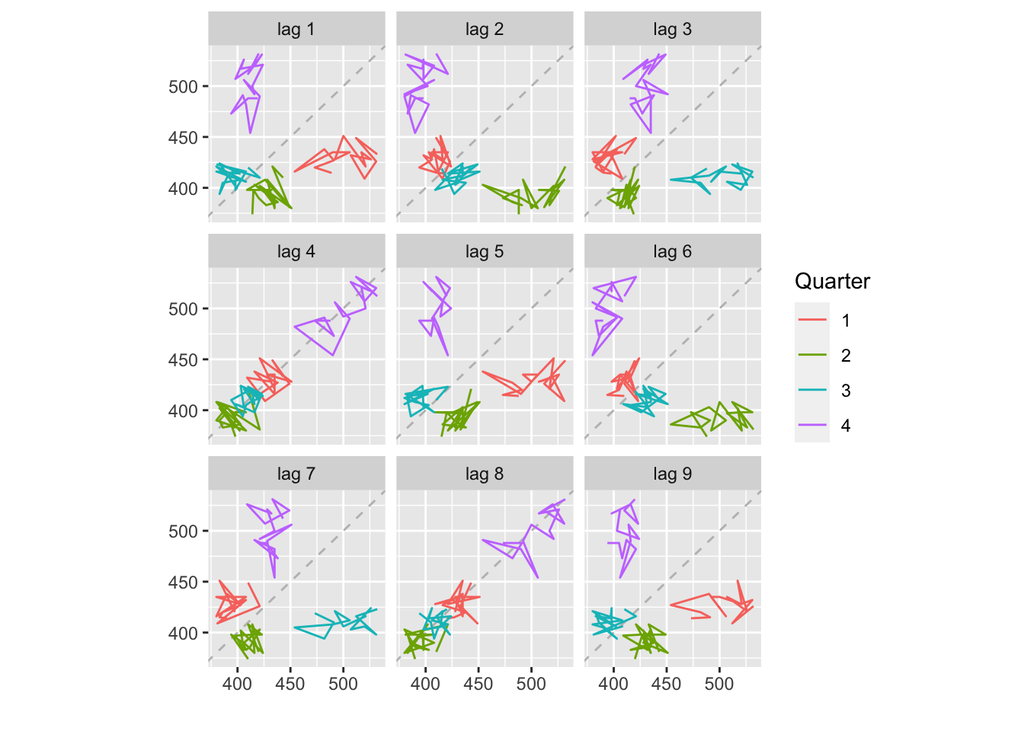

```r
beer2 <- window(ausbeer, start=1992)
gglagplot(beer2)
```

# 2.8 Autocorrelation

Correlation of the time series data with its *lagged values*. $T$ is the lenght of the time series.

$r_k = \frac{\sum_{t=k+1}^T(y_t-\bar{y})(y_{t-k}-\bar{y})}{\sum_{t=1}^T(y_t-\bar{y})^2}$

Example

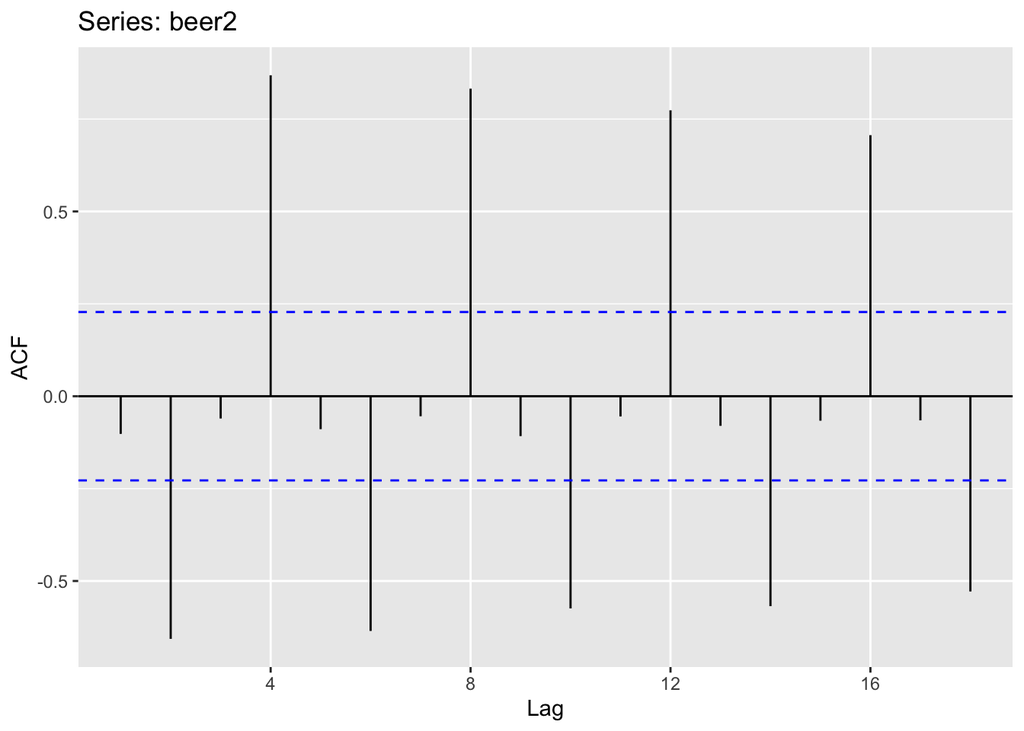

```r
ggAcf(beer2)
```

In an ACF, trended time series tend to have positive values that slowly decrease as the lag increase. When it’s seasonal, ACF is larger on the seaonal lags. If both, there is a combination of pattern from trend and season.

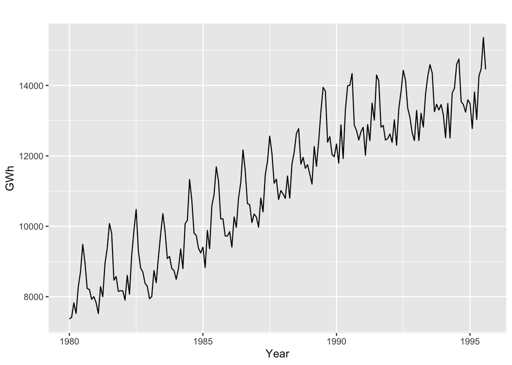

```r
aelec <- window(elec, start=1980)
autoplot(aelec) + xlab("Year") + ylab("GWh")
```

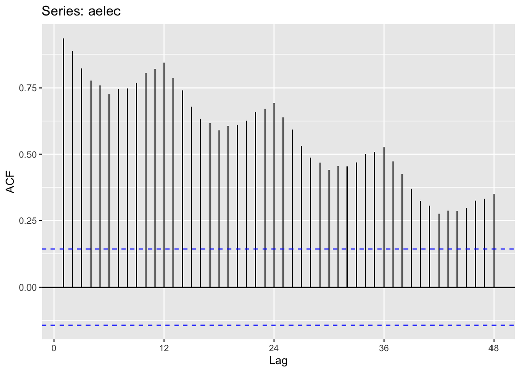

```r
ggAcf(aelec, lag=48)
```

# 2.9 White noise

If the time series show no autocorrelation. Not necessarily equal to zero, we expect at least 95% of the spikes in ACF plot to lie within $\pm2/\sqrt{T}$.

Example

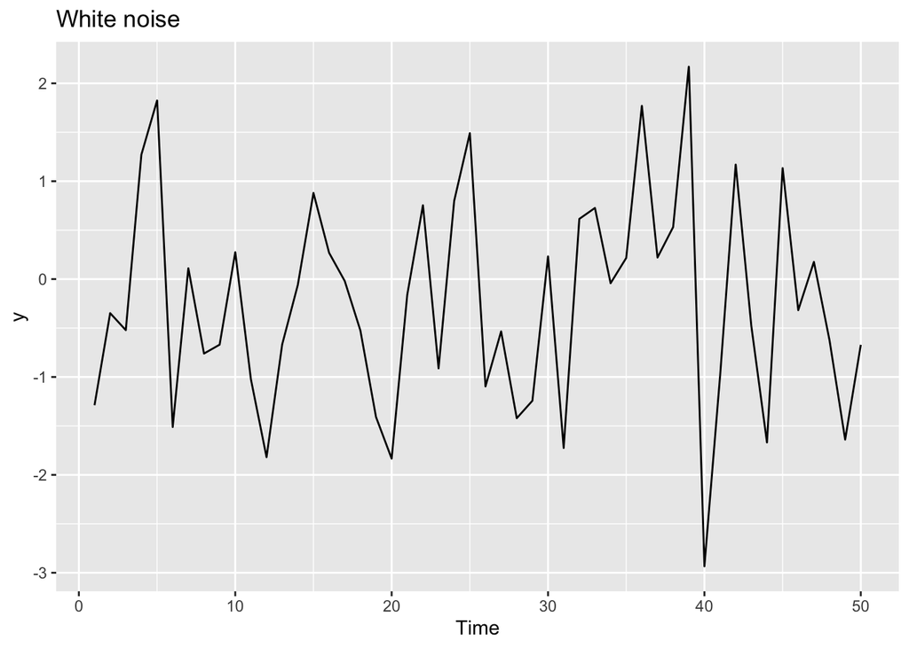

```r
set.seed(30)
y <- ts(rnorm(50))
autoplot(y) + ggtitle("White noise")
```

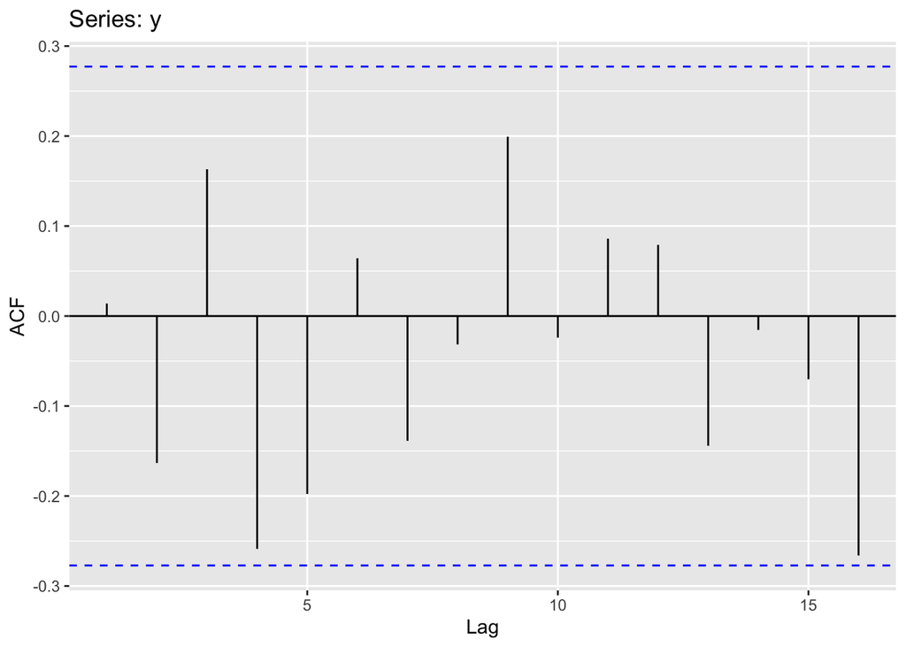

```r
ggAcf(y)
```